# KRT leaf ATAC preprocessing haplotype 1

Anne Pavia

2025-June-3

# Packages

```r
library(showtext)
```

#WD paste into terminal: setwd(‘/scratch/ac05869/10X_Multiome/KRT_leaf/ATAC_analysis/wd’) cd /scratch/ac05869/10X_Multiome/KRT_leaf/ATAC_analysis/wd

# KRT_AC_AE: Rep 1

## Data

```r
KRT1_counts <- Read10X_h5(filename = "../AC_cellranger_out/filtered_feature_bc_matrix.h5")
```

```
Genome matrix has multiple modalities, returning a list of matrices for this genome
```

```r
KRT1 <- CreateSeuratObject(
  counts = KRT1_counts$`Gene Expression`,
  assay = "RNA",
  project = "Rep 1"
)
KRT1[["ATAC"]] <- CreateChromatinAssay(
  counts = KRT1_counts$Peaks,
  sep = c(":", "-"),
  fragments = "../AC_cellranger_out/atac_fragments.tsv.gz"
)
KRT1
```

```
An object of class Seurat
138322 features across 5271 samples within 2 assays
Active assay: RNA (51396 features, 0 variable features)
 1 layer present: counts
 1 other assay present: ATAC
```

```r
#138322 features
#5271 samples
#2 assays: counts('Gene Expression) and ATAC(chromatin assay)
```

138322 features 5271 samples 2 assays: counts(’Gene Expression) and ATAC(chromatin assay)

## Filter nuclei

```r
DefaultAssay(KRT1) <- "ATAC"
KRT1 <- NucleosomeSignal(object = KRT1)
```

[output not shown]

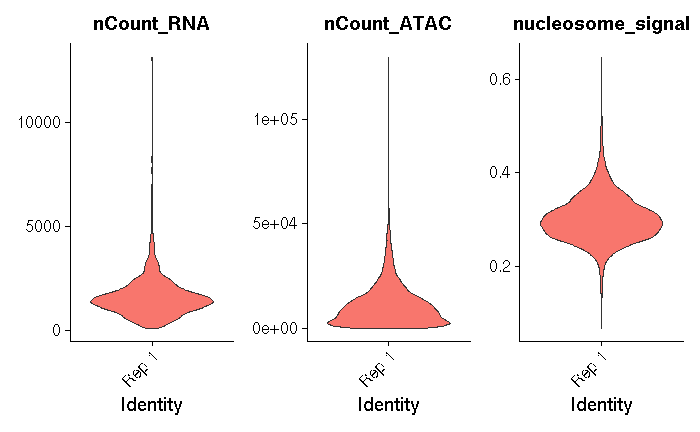

```r
VlnPlot(
  object = KRT1,
  features = c('nCount_RNA', 'nCount_ATAC',
               'nucleosome_signal'),
  pt.size = 0,
  ncol = 3
)
```

```r
NA
NA
```

[figure not shown]

```r
KRT1 <- subset(
  x = KRT1,
  subset =  nCount_ATAC < 40000 &
    nCount_RNA < 5000 &
    nCount_ATAC > 3000 &
    nCount_RNA > 300 &
    nucleosome_signal < 2
)

KRT1
```

[output not shown]

## GEX processing

```r
DefaultAssay(KRT1) <- "RNA"
KRT1 <- SCTransform(KRT1)
```

[output not shown]

```r
KRT1 <- RunPCA(KRT1)
```

```
PC_ 1
Positive:  Mitsp.v1.05-1G007670, Mitsp.v1.06-1G020880, Mitsp.v1.21-1G000890, Mitsp.v1.07-1G022280, Mitsp.v1.01-1G003380, Mitsp.v1.16-1G018750, Mitsp.v1.07-1G009110, Mitsp.v1.17-1G008250, Mitsp.v1.10-1G003920, Mitsp.v1.01-1G003350
       Mitsp.v1.07-1G020370, Mitsp.v1.14-1G020660, Mitsp.v1.14-1G007500, Mitsp.v1.10-1G013530, Mitsp.v1.08-1G004440, Mitsp.v1.14-1G005940, Mitsp.v1.17-1G017460, Mitsp.v1.05-1G028330, Mitsp.v1.22-1G002690, Mitsp.v1.22-1G015510
       Mitsp.v1.10-1G011990, Mitsp.v1.03-1G012720, Mitsp.v1.03-1G020350, Mitsp.v1.11-1G018930, Mitsp.v1.18-1G015160, Mitsp.v1.07-1G020800, Mitsp.v1.07-1G014230, Mitsp.v1.12-1G022360, Mitsp.v1.14-1G013690, Mitsp.v1.02-1G002920
Negative:  Mitsp.v1.20-1G001650, Mitsp.v1.22-1G018870, Mitsp.v1.11-1G014280, Mitsp.v1.12-1G016020, Mitsp.v1.22-1G013240, Mitsp.v1.14-1G014120, Mitsp.v1.16-1G017060, Mitsp.v1.16-1G018340, Mitsp.v1.03-1G003330, Mitsp.v1.21-1G003920
       Mitsp.v1.05-1G027870, Mitsp.v1.09-1G009240, Mitsp.v1.15-1G016020, Mitsp.v1.09-1G001060, Mitsp.v1.05-1G014230, Mitsp.v1.22-1G009970, Mitsp.v1.04-1G012540, Mitsp.v1.03-1G022840, Mitsp.v1.11-1G014930, Mitsp.v1.17-1G016490
       Mitsp.v1.15-1G011520, Mitsp.v1.16-1G016820, Mitsp.v1.07-1G005890, Mitsp.v1.11-1G013270, Mitsp.v1.21-1G011840, Mitsp.v1.02-1G007450, Mitsp.v1.12-1G003430, Mitsp.v1.15-1G019950, Mitsp.v1.11-1G019150, Mitsp.v1.21-1G011560
PC_ 2
Positive:  Mitsp.v1.06-1G004250, Mitsp.v1.03-1G018410, Mitsp.v1.20-1G017060, Mitsp.v1.04-1G012700, Mitsp.v1.03-1G006020, Mitsp.v1.05-1G022630, Mitsp.v1.07-1G009260, Mitsp.v1.04-1G006810, Mitsp.v1.22-1G003190, Mitsp.v1.08-1G017180
       Mitsp.v1.07-1G007720, Mitsp.v1.04-1G012840, Mitsp.v1.01-1G013930, Mitsp.v1.10-1G014090, Mitsp.v1.16-1G000900, Mitsp.v1.16-1G012910, Mitsp.v1.S000450, Mitsp.v1.19-1G011440, Mitsp.v1.04-1G008440, Mitsp.v1.01-1G010550
       Mitsp.v1.12-1G010890, Mitsp.v1.07-1G017330, Mitsp.v1.07-1G024090, Mitsp.v1.07-1G000940, Mitsp.v1.10-1G007310, Mitsp.v1.12-1G016220, Mitsp.v1.16-1G007540, Mitsp.v1.20-1G015810, Mitsp.v1.11-1G011490, Mitsp.v1.09-1G009510
Negative:  Mitsp.v1.20-1G001650, Mitsp.v1.22-1G018870, Mitsp.v1.11-1G014280, Mitsp.v1.12-1G016020, Mitsp.v1.22-1G013240, Mitsp.v1.05-1G007670, Mitsp.v1.06-1G020880, Mitsp.v1.07-1G022280, Mitsp.v1.21-1G000890, Mitsp.v1.14-1G014120
       Mitsp.v1.16-1G018750, Mitsp.v1.16-1G017060, Mitsp.v1.01-1G003380, Mitsp.v1.03-1G003330, Mitsp.v1.07-1G009110, Mitsp.v1.16-1G018340, Mitsp.v1.01-1G003350, Mitsp.v1.17-1G008250, Mitsp.v1.10-1G003920, Mitsp.v1.07-1G020370
       Mitsp.v1.14-1G007500, Mitsp.v1.14-1G020660, Mitsp.v1.10-1G013530, Mitsp.v1.08-1G004440, Mitsp.v1.14-1G005940, Mitsp.v1.17-1G017460, Mitsp.v1.22-1G002690, Mitsp.v1.22-1G015510, Mitsp.v1.05-1G028330, Mitsp.v1.10-1G011990
PC_ 3
Positive:  Mitsp.v1.11-1G020410, Mitsp.v1.11-1G013920, Mitsp.v1.01-1G009630, Mitsp.v1.11-1G014890, Mitsp.v1.02-1G013130, Mitsp.v1.14-1G001080, Mitsp.v1.12-1G016220, Mitsp.v1.16-1G017040, Mitsp.v1.05-1G017590, Mitsp.v1.11-1G018480
       Mitsp.v1.09-1G008570, Mitsp.v1.06-1G014100, Mitsp.v1.01-1G006910, Mitsp.v1.05-1G021830, Mitsp.v1.16-1G012770, Mitsp.v1.09-1G011360, Mitsp.v1.04-1G022770, Mitsp.v1.14-1G001060, Mitsp.v1.12-1G021650, Mitsp.v1.01-1G013000
       Mitsp.v1.04-1G000790, Mitsp.v1.22-1G003520, Mitsp.v1.18-1G008070, Mitsp.v1.22-1G014850, Mitsp.v1.07-1G023600, Mitsp.v1.05-1G003690, Mitsp.v1.04-1G013000, Mitsp.v1.01-1G013330, Mitsp.v1.20-1G000700, Mitsp.v1.02-1G001470
Negative:  Mitsp.v1.03-1G018410, Mitsp.v1.06-1G004250, Mitsp.v1.22-1G003190, Mitsp.v1.05-1G007670, Mitsp.v1.12-1G010890, Mitsp.v1.04-1G006810, Mitsp.v1.07-1G024090, Mitsp.v1.06-1G020880, Mitsp.v1.01-1G013930, Mitsp.v1.S000450
       Mitsp.v1.07-1G009260, Mitsp.v1.07-1G022280, Mitsp.v1.07-1G000940, Mitsp.v1.04-1G012840, Mitsp.v1.10-1G007310, Mitsp.v1.04-1G012700, Mitsp.v1.09-1G009510, Mitsp.v1.16-1G007540, Mitsp.v1.19-1G011440, Mitsp.v1.21-1G000890
       Mitsp.v1.01-1G030950, Mitsp.v1.01-1G010550, Mitsp.v1.04-1G008440, Mitsp.v1.17-1G011570, Mitsp.v1.16-1G018750, Mitsp.v1.07-1G009110, Mitsp.v1.03-1G006020, Mitsp.v1.12-1G023710, Mitsp.v1.22-1G016240, Mitsp.v1.15-1G003470
PC_ 4
Positive:  Mitsp.v1.07-1G024090, Mitsp.v1.06-1G004250, Mitsp.v1.12-1G010890, Mitsp.v1.22-1G003190, Mitsp.v1.03-1G018410, Mitsp.v1.01-1G013930, Mitsp.v1.04-1G006810, Mitsp.v1.11-1G020410, Mitsp.v1.20-1G001650, Mitsp.v1.04-1G012760
```

[output cut: 12 more lines]

```r
KRT1 <- RunUMAP(KRT1, dims = 1:50, reduction.name = "umap.rna",
                reduction.kep = "rnaUMAP_")
```

## ATAC processing

```r
DefaultAssay(KRT1) <- "ATAC"
KRT1 <- FindTopFeatures(KRT1, min.cutoff = "q0")
KRT1 <- RunTFIDF(KRT1)
```

```
Performing TF-IDF normalization
```

```r
KRT1 <- RunSVD(KRT1)
```

```
Running SVD
Scaling cell embeddings
```

```r
KRT1 <- RunUMAP(KRT1, reduction = 'lsi', dims = 2:50, reduction.name = "umap.atac", reduction.key = "atacUMAP_")
```

```
Using method 'umap'
```

## Joint UMAP

```r
KRT1
```

```
An object of class Seurat
166516 features across 5271 samples within 3 assays
Active assay: ATAC (86926 features, 86926 variable features)
 2 layers present: counts, data
 2 other assays present: RNA, SCT
 5 dimensional reductions calculated: pca, umap.rna, lsi, umap.atac, wnn.umap
```

```r
KRT1 <- FindClusters(KRT1, graph.name = "wsnn", algorithm = 3)
```

```
Modularity Optimizer version 1.3.0 by Ludo Waltman and Nees Jan van Eck

Number of nodes: 5271
Number of edges: 221152

Running smart local moving algorithm...
```

```
Maximum modularity in 10 random starts: 0.8944
Number of communities: 21
Elapsed time: 2 seconds
```

```r
KRT1_rna <- DimPlot(KRT1, label = TRUE, repel = TRUE, reduction = "umap.rna") +
  NoLegend() +
  theme_void() +
  ggtitle("RNA")

KRT1_atac <- DimPlot(KRT1, label = TRUE, repel = TRUE, reduction = "umap.atac") +
  NoLegend() +
  theme_void()+
  ggtitle("ATAC")

KRT1_joint <- DimPlot(KRT1, label = TRUE, repel = TRUE, reduction = "wnn.umap") +
  NoLegend() +
  theme_void() +
  ggtitle("Joint")

wrap_plots(
  KRT1_rna, KRT1_atac, KRT1_joint
) &
  NoLegend() &
  theme(plot.title = element_text(hjust = 0.5)) &
  theme(plot.margin = margin(t = 0, r = 3, b = 0, l = 0.5, unit = "lines"))

ggsave("../R_output/KRT1_UMAPs.svg", height = 3, width = 8, bg = "white")
```

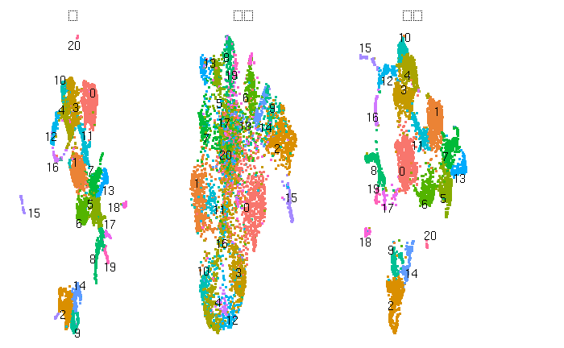

```r
ggsave("../R_output/KRT1_UMAPs.png", height = 3, width = 8, bg = "white")
```

# Write out filtered object

```r
KRT1$run <- "KRT1"
DefaultAssay(KRT1) <- "RNA"

KRT1
```

```
An object of class Seurat
166516 features across 5271 samples within 3 assays
Active assay: RNA (51396 features, 0 variable features)
 1 layer present: counts
 2 other assays present: ATAC, SCT
 5 dimensional reductions calculated: pca, umap.rna, lsi, umap.atac, wnn.umap
```

```r
saveRDS(KRT1, "../R_output/KRT1_filtered.Rds")
```

KRT1: 5271 nuclei

```r
KRT1$nCount_RNA %>% summary()
```

```
   Min. 1st Qu.  Median    Mean 3rd Qu.    Max.
    103    1031    1451    1580    1940   13141
```

```r
KRT1$nFeature_RNA %>% summary()
```

```
   Min. 1st Qu.  Median    Mean 3rd Qu.    Max.
     99     856    1162    1212    1488    7062
```

```r
KRT1$nCount_ATAC %>% summary()
```

```
   Min. 1st Qu.  Median    Mean 3rd Qu.    Max.
    119    3876    8839   11227   15082  129690
```

```r
KRT1$nFeature_ATAC %>% summary()
```

```
   Min. 1st Qu.  Median    Mean 3rd Qu.    Max.
     61    1871    4010    4850    6598   35421
```

Min. 1st Qu. Median Mean 3rd Qu. Max. 103 1031 1451 1580 1940 13141 Min. 1st Qu. Median Mean 3rd Qu. Max. 99 856 1162 1212 1488 7062 Min. 1st Qu. Median Mean 3rd Qu. Max. 119 3876 8839 11227 15082 129690 Min. 1st Qu. Median Mean 3rd Qu. Max. 61 1871 4010 4850 6598 35421

# KRT_AD_AF: Rep 2 (KRT2)

## Data

```r
KRT2_counts <- Read10X_h5(filename = "../AD_cellranger_out/filtered_feature_bc_matrix.h5")
```

```
Genome matrix has multiple modalities, returning a list of matrices for this genome
```

```r
KRT2 <- CreateSeuratObject(
  counts = KRT2_counts$`Gene Expression`,
  assay = "RNA",
  project = "Rep 2"
)
KRT2[["ATAC"]] <- CreateChromatinAssay(
  counts = KRT2_counts$Peaks,
  sep = c(":", "-"),
  fragments = "../AD_cellranger_out/atac_fragments.tsv.gz"
)
KRT2
```

```
An object of class Seurat
101664 features across 5322 samples within 2 assays
Active assay: RNA (51396 features, 0 variable features)
 1 layer present: counts
 1 other assay present: ATAC
```

101664 features across 5322 samples within 2 assays

## Filter nuclei

```r
DefaultAssay(KRT2) <- "ATAC"
KRT2 <- NucleosomeSignal(object = KRT2)
```

[output not shown]

[figure not shown]

```r
VlnPlot(
  object = KRT2,
  features = c('nCount_RNA', 'nCount_ATAC',
               'nucleosome_signal'),
  pt.size = 0,
  ncol = 3
)
```

```r
NA
NA
```

```r
C<- KRT2$nCount_RNA %>%
  as.data.frame() %>%
  ggplot(aes(x = `.`)) +
  geom_histogram(bins = 100, color = "white") +
  geom_vline(xintercept = 5000, color = "tomato1") +
  geom_vline(xintercept = 500, color = "tomato1") +
  ggtitle("Filtering nCount_RNA") +
  theme_classic()

D<- KRT2$nCount_ATAC %>%
  as.data.frame() %>%
  ggplot(aes(x = `.`)) +
  geom_histogram(bins = 100, color = "white") +
  geom_vline(xintercept = 40000, color = "tomato1") +
  geom_vline(xintercept = 2000, color = "tomato") +
  ggtitle("Filtering nCount_ATAC") +
  theme_classic()

filtering <-
  wrap_plots(C + labs(tag = "(a)"),
           D + labs(tag = "(b)"),
           ncol = 1, nrow = 2,
           widths = c(1),
           heights = c(0.5, 0.5))
filtering
ggsave(file = "../R_output/KRT_AD_AF_filter.svg", height = 4, width = 5, bg = "white")
```

[figure not shown]

```r
ggsave(file = "../R_output/KRT_AD_AF_filter.png", height = 4, width = 5, bg = "white")
```

```r
KRT2 <- subset(
  x = KRT2,
  subset =  nCount_ATAC < 40000 &
    nCount_RNA < 5000 &
    nCount_ATAC > 2000 &
    nCount_RNA > 500 &
    nucleosome_signal < 2
)

KRT2
```

```
An object of class Seurat
101664 features across 4262 samples within 2 assays
Active assay: ATAC (50268 features, 0 variable features)
 2 layers present: counts, data
 1 other assay present: RNA
```

101664 features across 4262 samples

## GEX processing

```r
DefaultAssay(KRT2) <- "RNA"
KRT2 <- SCTransform(KRT2)
```

[output not shown]

```r
KRT2 <- RunPCA(KRT2)
```

```
PC_ 1
Positive:  Mitsp.v1.07-1G024090, Mitsp.v1.01-1G013930, Mitsp.v1.05-1G005440, Mitsp.v1.16-1G000900, Mitsp.v1.05-1G005430, Mitsp.v1.04-1G012700, Mitsp.v1.12-1G010890, Mitsp.v1.09-1G009510, Mitsp.v1.08-1G016600, Mitsp.v1.04-1G019770
       Mitsp.v1.03-1G012670, Mitsp.v1.19-1G000370, Mitsp.v1.04-1G023130, Mitsp.v1.09-1G015800, Mitsp.v1.07-1G000940, Mitsp.v1.12-1G023710, Mitsp.v1.06-1G004250, Mitsp.v1.16-1G002160, Mitsp.v1.15-1G003830, Mitsp.v1.04-1G008440
       Mitsp.v1.08-1G017180, Mitsp.v1.22-1G003190, Mitsp.v1.16-1G007860, Mitsp.v1.08-1G006560, Mitsp.v1.01-1G030950, Mitsp.v1.19-1G000520, Mitsp.v1.18-1G008560, Mitsp.v1.22-1G007920, Mitsp.v1.10-1G014100, Mitsp.v1.16-1G007540
Negative:  Mitsp.v1.11-1G020410, Mitsp.v1.01-1G009630, Mitsp.v1.11-1G014890, Mitsp.v1.05-1G017590, Mitsp.v1.09-1G008570, Mitsp.v1.11-1G018480, Mitsp.v1.11-1G013920, Mitsp.v1.16-1G012770, Mitsp.v1.06-1G003260, Mitsp.v1.05-1G021830
       Mitsp.v1.01-1G013330, Mitsp.v1.02-1G013130, Mitsp.v1.09-1G011360, Mitsp.v1.01-1G006910, Mitsp.v1.14-1G001080, Mitsp.v1.12-1G016220, Mitsp.v1.03-1G006930, Mitsp.v1.01-1G021100, Mitsp.v1.02-1G012400, Mitsp.v1.16-1G017040
       Mitsp.v1.02-1G001470, Mitsp.v1.18-1G008070, Mitsp.v1.04-1G013000, Mitsp.v1.04-1G022770, Mitsp.v1.06-1G001520, Mitsp.v1.21-1G006130, Mitsp.v1.07-1G017830, Mitsp.v1.17-1G016510, Mitsp.v1.21-1G000620, Mitsp.v1.20-1G000700
PC_ 2
Positive:  Mitsp.v1.11-1G020410, Mitsp.v1.07-1G024090, Mitsp.v1.01-1G013930, Mitsp.v1.11-1G014890, Mitsp.v1.05-1G017590, Mitsp.v1.01-1G009630, Mitsp.v1.05-1G005440, Mitsp.v1.12-1G010890, Mitsp.v1.16-1G000900, Mitsp.v1.05-1G005430
       Mitsp.v1.11-1G018480, Mitsp.v1.09-1G008570, Mitsp.v1.05-1G021830, Mitsp.v1.08-1G016600, Mitsp.v1.09-1G009510, Mitsp.v1.01-1G013330, Mitsp.v1.14-1G001080, Mitsp.v1.02-1G013130, Mitsp.v1.03-1G012670, Mitsp.v1.19-1G000370
       Mitsp.v1.06-1G003260, Mitsp.v1.03-1G006930, Mitsp.v1.16-1G012770, Mitsp.v1.09-1G011360, Mitsp.v1.01-1G021100, Mitsp.v1.S000540, Mitsp.v1.02-1G001470, Mitsp.v1.21-1G003490, Mitsp.v1.16-1G002160, Mitsp.v1.07-1G017830
Negative:  Mitsp.v1.08-1G007110, Mitsp.v1.09-1G009240, Mitsp.v1.13-1G006850, Mitsp.v1.05-1G004410, Mitsp.v1.S006450, Mitsp.v1.12-1G018260, Mitsp.v1.18-1G006400, Mitsp.v1.02-1G017020, Mitsp.v1.19-1G011610, Mitsp.v1.10-1G020590
       Mitsp.v1.16-1G012910, Mitsp.v1.18-1G001700, Mitsp.v1.S000310, Mitsp.v1.19-1G012530, Mitsp.v1.15-1G009340, Mitsp.v1.04-1G001680, Mitsp.v1.10-1G014090, Mitsp.v1.21-1G003290, Mitsp.v1.06-1G021320, Mitsp.v1.22-1G018000
       Mitsp.v1.07-1G007720, Mitsp.v1.15-1G002840, Mitsp.v1.14-1G009040, Mitsp.v1.03-1G020130, Mitsp.v1.06-1G019420, Mitsp.v1.09-1G003460, Mitsp.v1.05-1G003220, Mitsp.v1.09-1G006510, Mitsp.v1.11-1G013550, Mitsp.v1.16-1G013400
PC_ 3
Positive:  Mitsp.v1.16-1G012910, Mitsp.v1.03-1G006020, Mitsp.v1.07-1G007720, Mitsp.v1.12-1G016220, Mitsp.v1.21-1G003290, Mitsp.v1.18-1G001700, Mitsp.v1.20-1G017060, Mitsp.v1.05-1G022630, Mitsp.v1.08-1G006740, Mitsp.v1.11-1G013920
       Mitsp.v1.22-1G018000, Mitsp.v1.16-1G012920, Mitsp.v1.01-1G003680, Mitsp.v1.04-1G013960, Mitsp.v1.07-1G005410, Mitsp.v1.18-1G008070, Mitsp.v1.15-1G002840, Mitsp.v1.09-1G010090, Mitsp.v1.16-1G013400, Mitsp.v1.07-1G003760
       Mitsp.v1.01-1G003240, Mitsp.v1.20-1G015810, Mitsp.v1.09-1G011090, Mitsp.v1.07-1G023670, Mitsp.v1.08-1G004180, Mitsp.v1.03-1G022430, Mitsp.v1.07-1G002560, Mitsp.v1.10-1G014030, Mitsp.v1.01-1G007030, Mitsp.v1.12-1G021650
Negative:  Mitsp.v1.17-1G002210, Mitsp.v1.09-1G017370, Mitsp.v1.21-1G000100, Mitsp.v1.11-1G020640, Mitsp.v1.17-1G002060, Mitsp.v1.18-1G006400, Mitsp.v1.06-1G020950, Mitsp.v1.22-1G001970, Mitsp.v1.16-1G003500, Mitsp.v1.12-1G011970
       Mitsp.v1.09-1G003530, Mitsp.v1.03-1G014470, Mitsp.v1.22-1G016960, Mitsp.v1.04-1G000410, Mitsp.v1.13-1G004950, Mitsp.v1.12-1G010630, Mitsp.v1.03-1G020130, Mitsp.v1.08-1G005750, Mitsp.v1.12-1G013560, Mitsp.v1.21-1G002940
       Mitsp.v1.16-1G017700, Mitsp.v1.16-1G012790, Mitsp.v1.01-1G027230, Mitsp.v1.05-1G021540, Mitsp.v1.01-1G028500, Mitsp.v1.15-1G010020, Mitsp.v1.12-1G020290, Mitsp.v1.15-1G003500, Mitsp.v1.13-1G015760, Mitsp.v1.15-1G019930
PC_ 4
Positive:  Mitsp.v1.18-1G008070, Mitsp.v1.01-1G003240, Mitsp.v1.11-1G013920, Mitsp.v1.04-1G013960, Mitsp.v1.11-1G018190, Mitsp.v1.12-1G021650, Mitsp.v1.20-1G008040, Mitsp.v1.14-1G011020, Mitsp.v1.02-1G007110, Mitsp.v1.21-1G008000
```

[output cut: 12 more lines]

```r
KRT2 <- RunUMAP(KRT2, dims = 1:50, reduction.name = "umap.rna",
                reduction.kep = "rnaUMAP_")
```

## ATAC processing

```r
KRT2 <- RunUMAP(KRT2, reduction = 'lsi', dims = 2:50, reduction.name = "umap.atac", reduction.key = "atacUMAP_")
```

```
Using method 'umap'
```

## Joint UMAP

```r
KRT2 <- FindMultiModalNeighbors(
  object = KRT2,
  reduction.list = list("pca", "lsi"),
  dims.list = list(1:50, 2:50),
  modality.weight.name = "RNA.weight",
  verbose = TRUE
)
```

```
Calculating cell-specific modality weights
Finding 20 nearest neighbors for each modality.
```

```
  |                                                  | 0 % ~calculating
  |+++++++++++++++++++++++++                         | 50% ~01s
  |++++++++++++++++++++++++++++++++++++++++++++++++++| 100% elapsed=02s
```

```
Calculating kernel bandwidths
```

```
  |                                                  | 0 % ~calculating
  |+++++++++++++++++++++++++                         | 50% ~00s
  |++++++++++++++++++++++++++++++++++++++++++++++++++| 100% elapsed=00s
```

[output not shown]

```
Constructing multimodal KNN graph
Constructing multimodal SNN graph
```

```r
# build a joint UMAP visualization
KRT2 <- RunUMAP(
  object = KRT2,
  nn.name = "weighted.nn",
  reduction.name = "wnn.umap",
  reduction.key = "wnnUMAP_"
)
```

```
Using method 'umap'
```

```r
KRT2 <- FindClusters(KRT2, graph.name = "wsnn", algorithm = 3)
```

```
Modularity Optimizer version 1.3.0 by Ludo Waltman and Nees Jan van Eck

Number of nodes: 4262
Number of edges: 191242

Running smart local moving algorithm...
```

```
Maximum modularity in 10 random starts: 0.9033
Number of communities: 19
Elapsed time: 1 seconds
```

```r
KRT2_rna <- DimPlot(KRT2, label = TRUE, repel = TRUE, reduction = "umap.rna") +
  NoLegend() +
  theme_void() +
  ggtitle("RNA")
```

[output not shown]

```r
KRT2_atac <- DimPlot(KRT2, label = TRUE, repel = TRUE, reduction = "umap.atac") +
  NoLegend() +
  theme_void()+
  ggtitle("ATAC")
```

[output not shown]

```r
KRT2_joint <- DimPlot(KRT2, label = TRUE, repel = TRUE, reduction = "wnn.umap") +
  NoLegend() +
  theme_void() +
  ggtitle("Joint")
```

[output not shown]

```r
wrap_plots(
  KRT2_rna, KRT2_atac, KRT2_joint
) &
  NoLegend() &
  theme(plot.title = element_text(hjust = 0.5)) &
  theme(plot.margin = margin(t = 0, r = 3, b = 0, l = 0.5, unit = "lines"))

ggsave("../R_output/KRT2_UMAPs.svg", height = 3, width = 8, bg = "white")
```

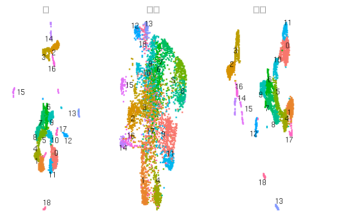

```r
ggsave("../R_output/KRT2_UMAPs.png", height = 3, width = 8, bg = "white")
```

# Write out filtered object

```r
KRT2$run <- "KRT2"
DefaultAssay(KRT2) <- "RNA"

KRT2
```

```
An object of class Seurat
129499 features across 4262 samples within 3 assays
Active assay: RNA (51396 features, 0 variable features)
 1 layer present: counts
 2 other assays present: ATAC, SCT
 5 dimensional reductions calculated: pca, umap.rna, lsi, umap.atac, wnn.umap
```

```r
saveRDS(KRT2, "../R_output/KRT2_filtered.Rds")
```

KRT2: 4262 nuclei

```r
KRT2$nCount_RNA %>% summary()
```

```
   Min. 1st Qu.  Median    Mean 3rd Qu.    Max.
    506    1269    1719    1818    2212    4979
```

```r
KRT2$nFeature_RNA %>% summary()
```

```
   Min. 1st Qu.  Median    Mean 3rd Qu.    Max.
    420    1008    1318    1361    1638    3239
```

```r
KRT2$nCount_ATAC %>% summary()
```

```
   Min. 1st Qu.  Median    Mean 3rd Qu.    Max.
   2017    5339    9258   11329   15200   39878
```

```r
KRT2$nFeature_ATAC %>% summary()
```

```
   Min. 1st Qu.  Median    Mean 3rd Qu.    Max.
    833    2490    4169    4854    6508   15036
```

Min. 1st Qu. Median Mean 3rd Qu. Max. 506 1269 1719 1818 2212 4979 Min. 1st Qu. Median Mean 3rd Qu. Max. 420 1008 1318 1361 1638 3239 Min. 1st Qu. Median Mean 3rd Qu. Max. 2017 5339 9258 11329 15200 39878 Min. 1st Qu. Median Mean 3rd Qu. Max. 833 2490 4169 4854 6508 15036